# Case Study 01

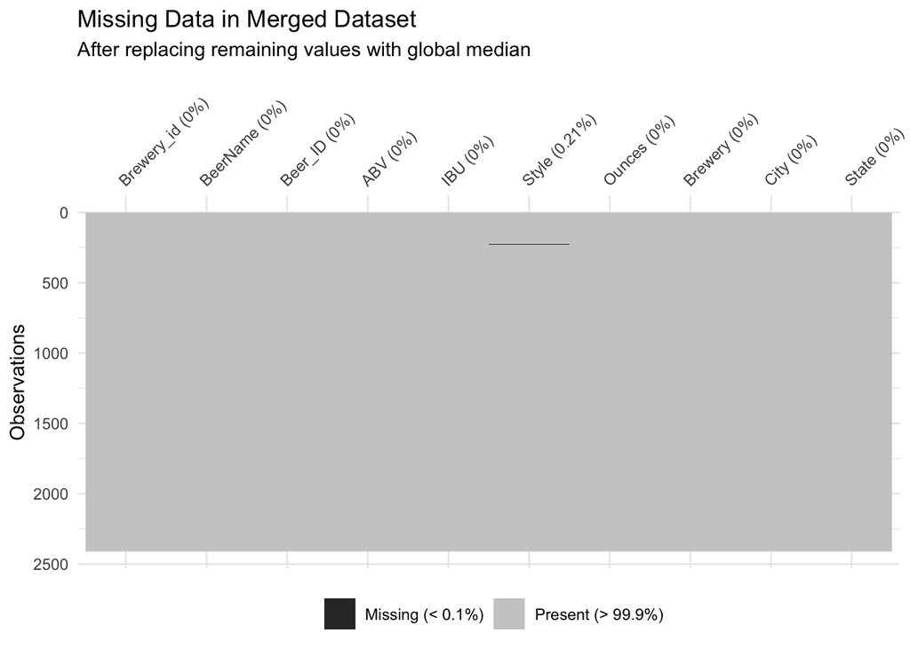

```r
# the percentage of missing values is rather small -> we will replace it with global median
brewByState$IBU[is.na(brewByState$IBU)]<-median(brewByState$IBU,na.rm=TRUE)

vis_miss(brewByState) + ggtitle("Missing Data in Merged Dataset", "After replacing remaining values with global median")
```

```r
#Show summary statistics for median ABV and IBU
brewByState.Stats <- brewByState %>% group_by(State) %>%
  dplyr::summarise(medianABV = median(ABV), medianIBU = median(IBU), maxABV = max(ABV), maxIBU = max(IBU))
brewByState.Stats
```

```
## # A tibble: 51 x 5
##    State medianABV medianIBU maxABV maxIBU
##    <chr>     <dbl>     <dbl>  <dbl>  <dbl>
##  1 " AK"    0.056       31    0.068     71
##  2 " AL"    0.06        39.5  0.093    103
##  3 " AR"    0.052       31    0.061     41
##  4 " AZ"    0.055       21.5  0.095     99
##  5 " CA"    0.058       40    0.099    115
##  6 " CO"    0.06        35    0.128    104
##  7 " CT"    0.06        31    0.09      91
##  8 " DC"    0.0625      27    0.092    115
##  9 " DE"    0.06        60.5  0.065     69
## 10 " FL"    0.0555      35.8  0.082     82
## # … with 41 more rows
```

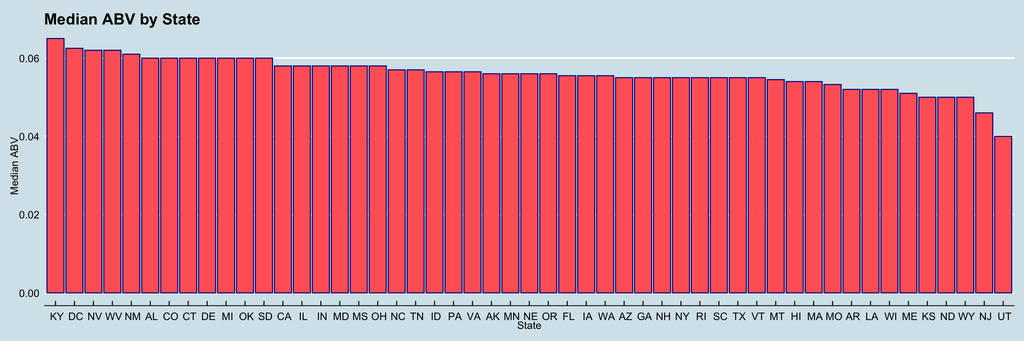

```r
#Print graph of Median ABV by State
brewByState.Stats %>% ggplot(aes(x = reorder(State, -medianABV) , y = medianABV)) +
  geom_bar(stat = "identity", color = "darkblue", fill = "#FF6666")+
  ggtitle("Median ABV by State") +
  xlab("State") + ylab("Median ABV") +
  theme_economist()
```

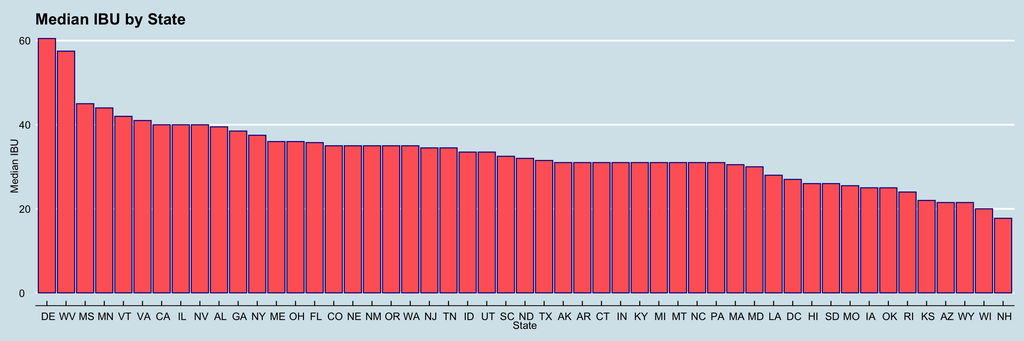

```r
#Print graph of Median IBU by State
brewByState.Stats %>% ggplot(aes(x = reorder(State, -medianIBU) , y = medianIBU)) +
  geom_bar(stat = "identity" , color = "darkblue", fill = "#FF6666")+
  ggtitle("Median IBU by State") +
  xlab("State") + ylab("Median IBU") +
  theme_economist()
```

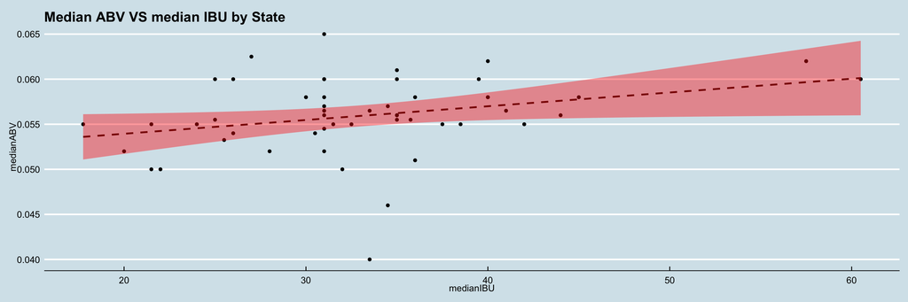

```r
#Print graph showing relationship between Median IBU and Median ABV
brewByState.Stats %>%
ggplot(aes(x =  medianIBU , y = medianABV)) + geom_point() +
  geom_smooth(method=lm, linetype="dashed",
              color="darkred", fill="red") +
  ggtitle("Median ABV VS median IBU by State")+
   theme_economist()
```

```r
#Calculate pearson correlation for median IBU and ABV
pearson.cor <- round(cor(brewByState.Stats$medianIBU, brewByState.Stats$medianABV),2)
pearson.cor
```

```
## [1] 0.29
```

```r
#Show beers in Delaware in West Virginia.. Only two beers in each state.
brewByState %>% filter(State == " DE")
```

```
##   Brewery_id            BeerName Beer_ID   ABV IBU                   Style
## 1        317    Appreciation Ale    1784 0.065  69            American IPA
## 2        540 Greenville Pale Ale     433 0.055  52 American Pale Ale (APA)
##   Ounces                        Brewery       City State
## 1     16 Iron Hill Brewery & Restaurant Wilmington    DE
## 2     12     Twin Lakes Brewing Company Greenville    DE
```

```r
brewByState %>% filter(State == " WV")
```

```
##   Brewery_id            BeerName Beer_ID   ABV IBU                   Style
## 1        157 Wild Trail Pale Ale    2314 0.057  44 American Pale Ale (APA)
## 2        157   Mothman Black IPA    2313 0.067  71      American Black Ale
##   Ounces                           Brewery      City State
## 1     12 Greenbrier Valley Brewing Company Lewisburg    WV
## 2     12 Greenbrier Valley Brewing Company Lewisburg    WV
```

## Question 5: MAX ABV, IBU by state

The state with the highest ABV value was Colorado, with an ABV of 12.8%. The state with the highest IBU was Oregon, with an IBU of 138.

```r
#Print the state with the maximum ABV value
brewByState[which.max(brewByState$ABV),]
```

```
##     Brewery_id                                             BeerName Beer_ID
## 375         52 Lee Hill Series Vol. 5 - Belgian Style Quadrupel Ale    2565
##       ABV IBU            Style Ounces                 Brewery    City State
## 375 0.128  24 Quadrupel (Quad)   19.2 Upslope Brewing Company Boulder    CO
```

```r
#Print the state with maximum IBU value
brewByState[which.max(brewByState$IBU),]
```

```
##      Brewery_id                  BeerName Beer_ID   ABV IBU
## 1857        375 Bitter Bitch Imperial IPA     980 0.082 138
##                               Style Ounces                 Brewery    City
## 1857 American Double / Imperial IPA     12 Astoria Brewing Company Astoria
##      State
## 1857    OR
```

## Question 6: Summary statistics ABV

The mean is larger than the median and this is a right-skewed distribution.

```r
#Print summary of ABV statistics by state.
summary(brewByState$ABV)
```

```
##    Min. 1st Qu.  Median    Mean 3rd Qu.    Max.
## 0.00100 0.05000 0.05600 0.05972 0.06700 0.12800
```

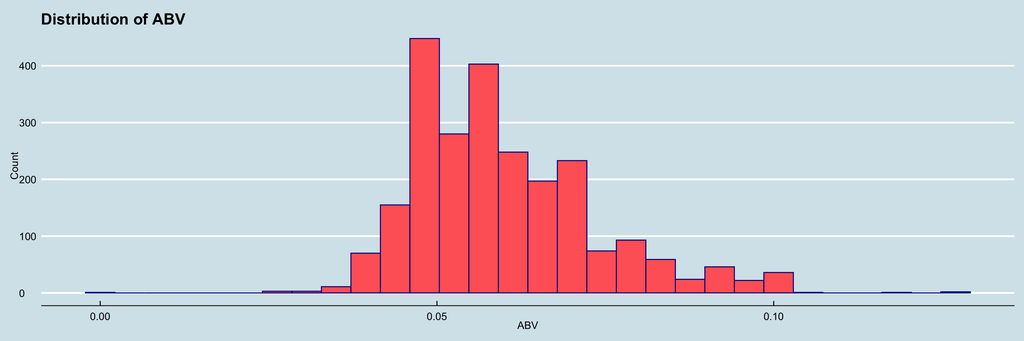

```r
#Print histogram of ABV values
brewByState  %>% ggplot(aes(ABV)) +
  geom_histogram( color = "darkblue", fill = "#FF6666") +
  ggtitle("Distribution of ABV") +
  xlab("ABV") + ylab("Count") +
  theme_economist()
```

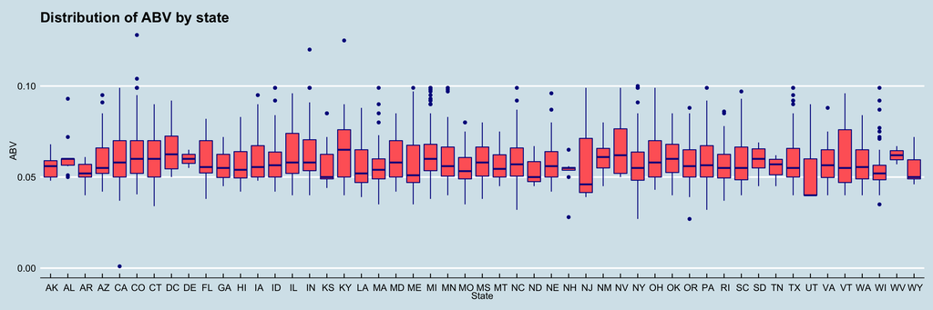

```r
#Print box plot of ABV values by State
ggplot(data=brewByState, aes(y=ABV,x=State)) +
  geom_boxplot(color = "darkblue", fill = "#FF6666") +
  ggtitle("Distribution of ABV by state") +
  xlab("State") + ylab("ABV") +
  theme_economist()
```

#Question 7: Correlation

After looking at the scatter plot below, we see there is a positive correlation between ABV and IBU, with a pearson correlation of .59.

```r
#Calculate pearson correlation for ABV and IBU
pearson.cor <- round(cor(brewByState$ABV, brewByState$IBU),2)
pearson.cor
```

```
## [1] 0.59
```

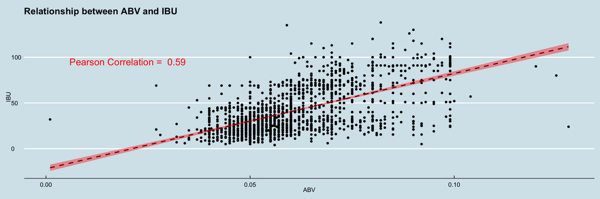

```r
#Print scatter plot of ABV vs IBU with pearson correlation value
brewByState %>%
ggplot(aes(x =  ABV , y = IBU)) + geom_point() +
  geom_smooth(method=lm, linetype="dashed",
              color="darkred", fill="red") +
  annotate(x=0.02, y=95,
           label= paste("Pearson Correlation = ", pearson.cor),
           geom="text", size=6, color = "red")+
  ggtitle("Relationship between ABV and IBU")+
   theme_economist()
```

#Question 8: KNN